# US Estimates of the number of females who have experienced FGM

### Overview & Motivation:

The Sustainable Development Goal (SDG) target 5.3 states that by 2030 all harmful practices, such as child, early and forced marriage, and female genital mutilation should be eliminated (WHO). It is estimated that 200 million girls in the world today have experienced female genital mutilation (FGM) (UNFPA). FGM is defined as all procedures that intentionally alter or cause injury to the female genital organs for non-medical reasons (WHO). The practice of FGM is a violation of human rights. Perpetuated by gender inequalities, FGM is harmful to the physical, emotional, and psychological health of girls and women.

FGM is commonly practiced in Sub-Saharan Africa and parts of the Middle East and Southeast Asia, with Somalia having the highest prevalence of FGM victims at 98% (UNFPA, 2019). Although it is often confined to a few countries, migration flows have removed the boundaries of FGM presence and brought the practice and its effects around the world. In the United States, an estimated 513,000 women are either at risk or have been subjected to FGM (Goldberg et al., 2016). Although these estimates were published in 2016, the data used in the analysis is from 2012. Thus, we are interested in updating the estimates of FGM in the United States. We believe this is important to inform future FGM research or interventions based in the United States.

### Related work:

The article with outdated estimates [here](https://www.ncbi.nlm.nih.gov/pmc/articles/PMC4765983/).

### Initial Questions:

Our primary interest was to update the estimates of FGM prevalence in the United States using the methods described in the study above. We were also interested in looking at the estimates by state and county, but later learned these data are not available after contacting the US Census Dissemination and Outreach Branch. Thus, we decided to calculate an estimate FGM prevalence based on data available on the national level.

Additionally, the methods that we planned to replicate included both females born in countries that practice FGM and their daughters. We were not able to find a usable data on these females’ daughters and believe that the methods used in the paper might be incorrect. We settled on doing a more conservative and valid estimate of FGM by just including females of all ages born in the countries that practice FGM, and excluding daughters that might be born in the US. We were able to find a variable in the ACS dataset that was “presence of daughter in the household”, but does not specify the number of daughters. We believe this is the indicator the authors may have used that could have resulted in an incorrect estimate and have contacted the authors for further clarification.

### Data Sources:

The data for the number of females who have migrated to the US from countries that practice FGM is from the American Community Survey (ACS), a survey conducted by the US census. From this data source, we extracted estimates of the place of birth of males and females in the United States. The place of birth includes both US states and countries outside of the US. ACS provides yearly estimates, but we chose a 5-year estimate from 2018 because these data have the largest sample size and the data is collected for all areas in the US, despite population size. Thus, we thought these data would give us the most accurate estimates of US female’s place of birth. The ACS data is not a census of all people across the US, but is instead a random sample from which an estimate is calculated.

We obtained data on FGM prevalence in country from UNICEF. They used data sources such as DHS, MICS, EDSF, which are large-scale population based global surveys. The dates for these population surveys range from 2004 to 2018. These are the most validated and updated estimates of FGM for females ages 15-49 available. This dataset includes 30 countries where FGM is practiced.

We renamed variables and names of countries to ensure the data matched, as needed, for merging. The ACS dataset was then filtered to only include countries where FGM is practiced according to our UNICEF data source. Data were merged based on country where FGM is practiced and country where females were born from filtered ACS dataset. We eliminated males from our dataset as well, as this is not a population of interest.

### Exploratory analysis:

The research study we attempted to replicate used two methods to estimate the FGM prevalence in the US.The first method assumed that the country-specific FGM prevalence among women and girls aged 15–49 years applied to all women and girls, and only required data on country of birth for these women. The second method applied country-specific FGM prevalence among women and girls aged 15–19 years in the country to women and girls younger than 20 years of age in the US, and applied the prevalence among women and girls aged 15–49 years to women and girls aged 20 years or older in the ACS-2012. The UNICEF FGM prevalence, which is the most recent and updated prevalence estimates, only provided estimates for all women ages 15-49. Although we could only replicate the first method, we believe this still provides a valid and important update on FGM prevalence in the U.S. Furthermore, the previous study was only able to capture estimates from 17 of the 27 countries that practice FGM. We were able to capture estimates from 20 of the 30 (now updated) countries that practice FGM.

We also created a world map of FGM prevalence to visualize the prevalence of FGM in countries where it is practiced. This map though does not represent migration patterns, which further emphasizes the necessity of our analysis.

### Major takeaways

Due to data constraints, we were only able to calculate a much more conservative estimate of FGM prevalence in the United States. We learned a lot about the assumptions researchers make when calculating these estimates and seriously question many of these assumptions, as these estimates may be used for future research or interventions. We also learned about the importance of writing clear methods so that they are easily reproducible.

```r
library(readxl)
library(dplyr)
```

```r
library(ggplot2)
library(tidyverse)
library(maps)
```

Import the ACS data. These data are from American Community Survey (ACS), a survey conducted by the US census. From this data source, we extracted estimates of the place of birth of males and females in the United States. The place of birth includes both US states and countries outside of the US. ACS provides yearly estimates, but we chose a 5-year estimate from 2018 because these data have the largest sample size and the data is collected for all areas in the US, despite population size. Thus, we thought these data would give us the most accurate estimates of US females’ place of birth.

```r
#Importing ACS data
pob_acs <- read.csv("BST 260 Project Data.csv")
```

Import data on FGM Prevalence. We obtained these data from UNICEF, who compiled the prevalence of FGM in countries. They used data sources such as DHS, MICS, EDSF, which are large-scale population based global surveys.

```r
#Importing FGM Prev data
fgm_prev <- read_xlsx("FGM-prevalence.xlsx")
```

Here we filter the ACS dataset to only include countries that practice FGM, according to the UNICEF dataset. Thus, we are left with a filtered dataset of ACS estimates of females in the US who were born in countries that practice FGM.

```r
#Filtering data set down to countries that practice FGM
pob_fgm <- pob_acs %>% filter(Place.of.birth %in% c("Yemen",
                                                  "Iraq",
                                                  "Cameroon",
                                                  "Egypt",
                                                  "Ethiopia",
                                                  "Eritrea",
                                                  "Gambia",
                                                  "Ghana",
                                                  "Guinea",
                                                  "Ivory Coast (2017 or later)",
                                                  "Kenya",
                                                  "Liberia",
                                                  "Nigeria",
                                                  "Senegal",
                                                  "Sierra Leone",
                                                  "Somalia",
                                                  "Sudan",
                                                  "Tanzania",
                                                  "Togo",
                                                  "Uganda"))
```

We changed the Place.of.birth variable name to Country, for future merging of the data. We also change the FGM prevalence among girls and women (%) variable name to fgm_prevalence, to make future coding easier.

```r
#Changing the variable names
pob_fgm <- pob_fgm %>% rename(Country = Place.of.birth)
fgm_prev <- fgm_prev %>% rename("fgm_prevalence" = "FGM prevalence among girls and women (%)")
```

To visualize the prevalence of FGM globally we plotted a map of FGM prevalence.

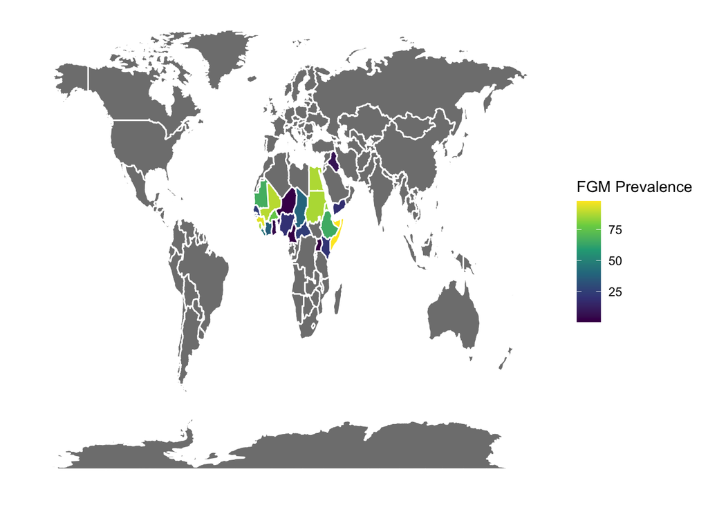

```r
#World Map
world_map = map_data("world")

#Rename any countries to match
world_map$region <- str_replace_all(world_map$region, "Ivory Coast", "Côte d'Ivoire")

world_map_fgm <- left_join(world_map,fgm_prev,by = c("region" = "Country"))


ggplot(world_map_fgm, aes(x = long, y = lat, group = group)) +
      geom_polygon(aes_string(fill="fgm_prevalence"), color = "white") +
     scale_fill_viridis_c(name = "FGM Prevalence")+
      theme(panel.grid.major = element_blank(),
            panel.background = element_blank(),
            axis.title = element_blank(),
            axis.text = element_blank(),
            axis.ticks = element_blank())
```

In order to make the country names match in the ACS data and UNICEF data, we changed the names of a few countries, so that we could later merge the datasets without error.

```r
# Changing the names of countries to match
pob_fgm$Country <- str_replace_all(pob_fgm$Country, "Ivory Coast \\(2017 or later\\)", "Côte d'Ivoire")
fgm_prev$Country <- str_replace_all(fgm_prev$Country, "United Republic of Tanzania", "Tanzania")
```

We joined the datasets into one final dataset for analysis. This final dataset has the number of females in the US who were born in countries that practice FGM, as well as the prevalence of FGM in that country.

```r
#Join the dataset
fgm_combined <- inner_join(pob_fgm, fgm_prev, by = c("Country"))
```

We removed the male and total column that are not needed for analysis.

```r
#Remove male and total population columns
fgm_combined <- fgm_combined[-c(2,3)]
```

To obtain the estimate the number of females living in the US who had experienced FGM, we created a new variable that was the multiplication of the country FGM estimate and the number of females born in that country, living in the US.

```r
#Estimate the number of females who have experienced FGM in US
fgm_combined$fgm_estimate <- fgm_combined$Female*(fgm_combined$fgm_prevalence/100)
```

We summarized (sum) the new variable calculated above to obtain the total number of females in the US who have experienced FGM.

```r
#Total number of females in the US who are have experienced FGM
fgm_combined %>% summarise(sum(fgm_estimate))
```

```
##   sum(fgm_estimate)
## 1          370054.9
```

We decided to create a few plots to visualize our results. Here we graph the number of females living in the US by their place of birth, only including countries that practice FGM.

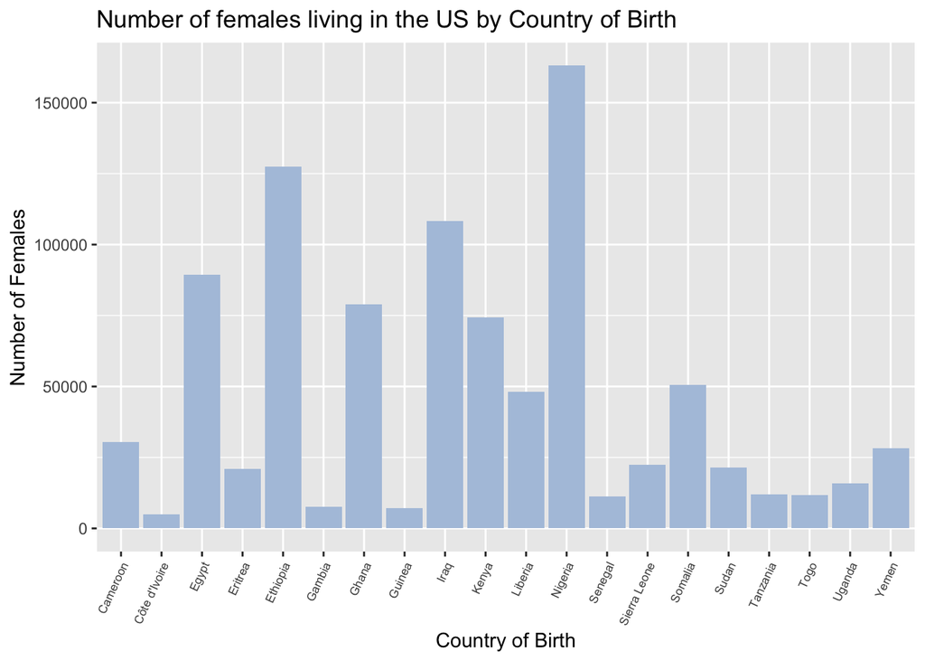

```r
fgm_combined %>%
  ggplot() +
  geom_bar(aes(x=Country, y = Female), stat = "identity", fill = "lightsteelblue") +
  xlab("Country of Birth") +
  ylab("Number of Females") +
  theme(axis.text.x = element_text(size = 6.5, angle = 65, hjust=1))+
  ggtitle("Number of females living in the US by Country of Birth")
```

Here we graph the prevalence of FGM (%) in each country that practices FGM. We created a world map to show FGM prevalence by country globally.

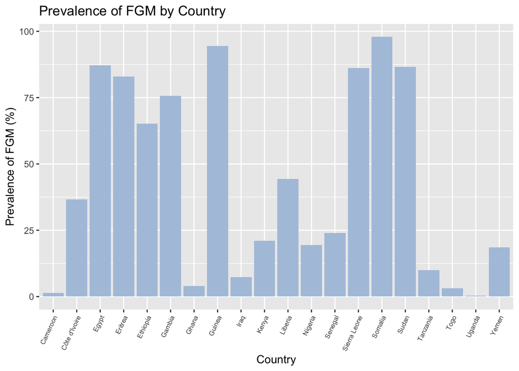

```r
fgm_combined %>%
  ggplot() +
  geom_bar(aes(x=Country, y = fgm_prevalence), stat = "identity", fill = "lightsteelblue") +
  xlab("Country") +
  ylab("Prevalence of FGM (%)") +
  theme(axis.text.x = element_text(size = 6.5, angle = 65, hjust=1))+
  ggtitle("Prevalence of FGM by Country")
```

Here we graph the estimates of females living in the US who have experienced FGM by their country of birth.

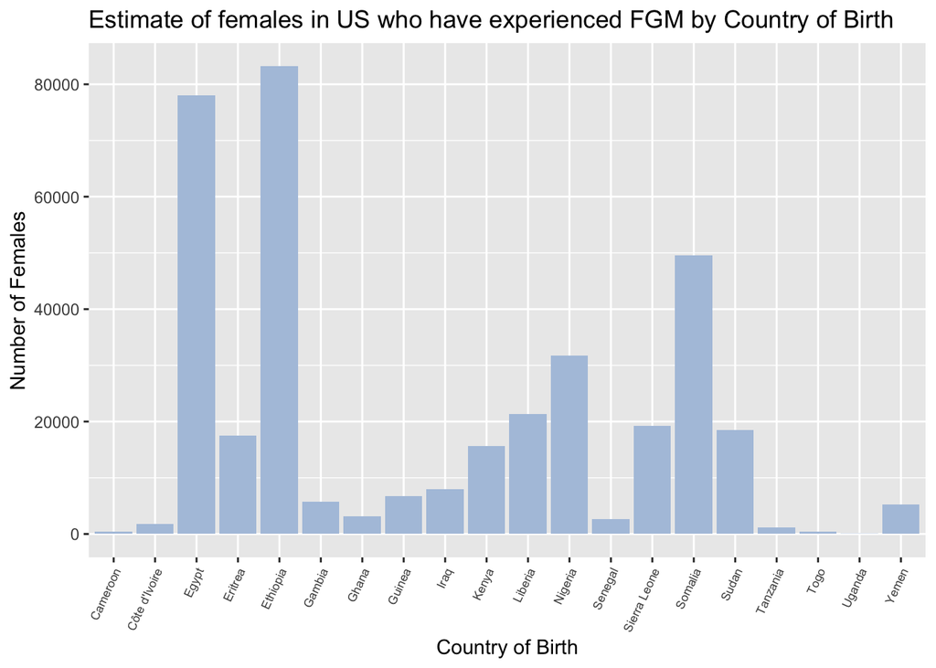

```r
fgm_combined %>%
  ggplot() +
  geom_bar(aes(x=Country, y = fgm_estimate), stat = "identity", fill = "lightsteelblue") +
  xlab("Country of Birth") +
  ylab("Number of Females") +
  theme(axis.text.x = element_text(size = 6.5, angle = 65, hjust=1))+
  ggtitle("Estimate of females in US who have experienced FGM by Country of Birth")
```